# Why CDF?

Patrick Altmeyer

07 October, 2020

## Why the CDF?

The authors have the following to say about this:

*We used the cumulative distribution because it highlights a change in the distribution, which is our key interest, and it does not require any user-defined tuning parameters. Histograms require the selection of a binwidth and density plots require user- defined smoothing parameters, which are subjective and will create different impressions depending on the choice made.*

I take their points, it is often easier to interpret CDFs (especially the y-axis). **But I still don’t think the choice between showing the PDF vs. the CDF is obvious. Using the CDF the authors’ point is illustrated through a kink around 1, while the point could have equally been made through showing the PDF and pointing to its mode (which some may find more appealing).**

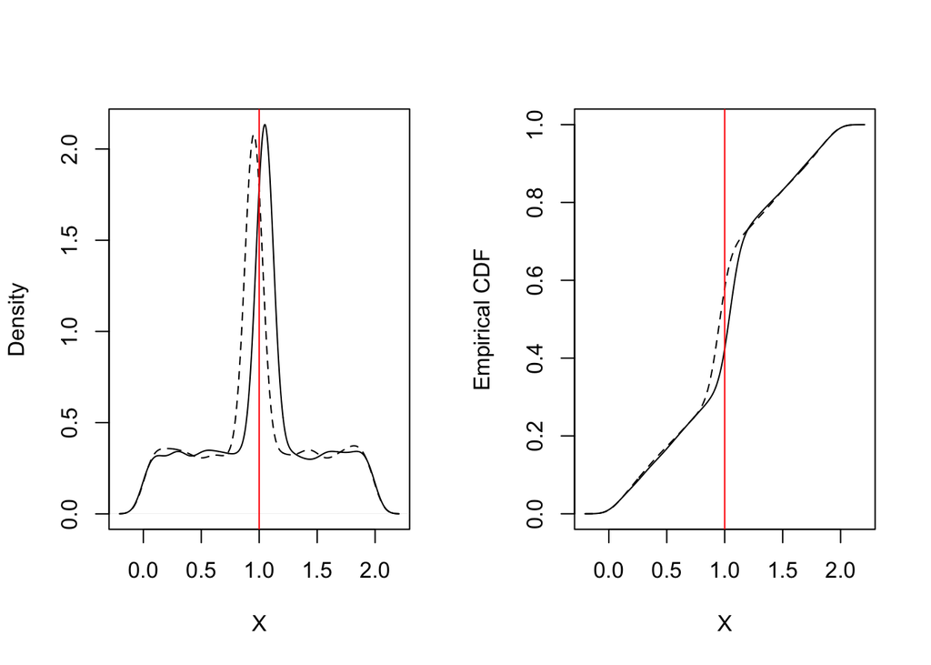

```r
a = runif(1000) # values between 0,1
b = rep(runif(200,1,1.1),5) # cluster of values between 1,1.05
c = runif(1000,1,2) # values between 1,2
X_lower = c(a,b,c)
a = runif(1000) # values between 0,1
b = rep(runif(200,0.9,1),5) # cluster of values between 1,1.05
c = runif(1000,1,2) # values between 1,2
X_upper = c(a,b,c)
# Plots
dens_lower = density(X_lower)
dens_upper = density(X_upper)
par(mfrow=c(1,2))
plot(dens_lower, main = NA, xlab="X") # density
lines(dens_upper, lty=2)
abline(v=1, col="red")
ecdf_lower = cumsum(dens_lower$y/sum(dens_lower$y)) # empirical cdf
ecdf_upper = cumsum(dens_upper$y/sum(dens_upper$y)) # empirical cdf
plot(x=dens_lower$x, y=ecdf_lower, t="l", xlab = "X", ylab="Empirical CDF")
lines(x=dens_upper$x,ecdf_upper, lty=2)
abline(v=1, col="red")
```

[^1]: Note that I am referring to the lower CI bound here, but the logic is of course very similar for the upper bound.